# Assignment #7

20141831 박석환

2020 6 12

## Content-Based Movie Recommendation using Clustering

“movie.csv” 파일은 movielens 데이터셋에 포함되어 있는 1,664개의 영화에 대한 장르 정보를 포함하고 있다. 첫번째 column은 영화의 제목(Title)을 의미하고, 나머지 19개의 column은 각 영화가 19개의 장르에 포함되는지 여부를 아래 예와 같이 0/1로 나타내고 있다. 하나의 영화는 여러 장르에 포함될 수 있다.

```r
# 라이브러리 추가
library(arules)
library(ggplot2)
library(dplyr)
```

### 1.각 장르 별로 몇 개의 영화를 포함하고 있는지 계산해 보자. 가장 많은 영화를 포함하는 장르와 가장 적은 영화를 포함하는 장르는 무엇인가?

```r
# 데이터 읽어오기
setwd("C:/Users/user/Desktop/R ex/#7")
movie <- read.csv("movie.csv", stringsAsFactors = FALSE)

# movie dataframe 구조
str(movie)
```

```
## 'data.frame':    1664 obs. of  20 variables:
##  $ Title      : chr  "Toy Story (1995)" "GoldenEye (1995)" "Four Rooms (1995)" "Get Shorty (1995)" ...
##  $ Unknown    : int  0 0 0 0 0 0 0 0 0 0 ...
##  $ Action     : int  0 1 0 1 0 0 0 0 0 0 ...
##  $ Adventure  : int  0 1 0 0 0 0 0 0 0 0 ...
##  $ Animation  : int  1 0 0 0 0 0 0 0 0 0 ...
##  $ Childrens  : int  1 0 0 0 0 0 0 1 0 0 ...
##  $ Comedy     : int  1 0 0 1 0 0 0 1 0 0 ...
##  $ Crime      : int  0 0 0 0 1 0 0 0 0 0 ...
##  $ Documentary: int  0 0 0 0 0 0 0 0 0 0 ...
##  $ Drama      : int  0 0 0 1 1 1 1 1 1 1 ...
##  $ Fantasy    : int  0 0 0 0 0 0 0 0 0 0 ...
##  $ FilmNoir   : int  0 0 0 0 0 0 0 0 0 0 ...
##  $ Horror     : int  0 0 0 0 0 0 0 0 0 0 ...
##  $ Musical    : int  0 0 0 0 0 0 0 0 0 0 ...
##  $ Mystery    : int  0 0 0 0 0 0 0 0 0 0 ...
##  $ Romance    : int  0 0 0 0 0 0 0 0 0 0 ...
##  $ SciFi      : int  0 0 0 0 0 0 1 0 0 0 ...
##  $ Thriller   : int  0 1 1 0 1 0 0 0 0 0 ...
##  $ War        : int  0 0 0 0 0 0 0 0 0 1 ...
##  $ Western    : int  0 0 0 0 0 0 0 0 0 0 ...
```

```r
# 제목열을 제외하고 장르에 대한 정보 추출
movie_colsum <- movie[,-1]
str(movie_colsum)
```

```
## 'data.frame':    1664 obs. of  19 variables:
##  $ Unknown    : int  0 0 0 0 0 0 0 0 0 0 ...
##  $ Action     : int  0 1 0 1 0 0 0 0 0 0 ...
##  $ Adventure  : int  0 1 0 0 0 0 0 0 0 0 ...
##  $ Animation  : int  1 0 0 0 0 0 0 0 0 0 ...
##  $ Childrens  : int  1 0 0 0 0 0 0 1 0 0 ...
##  $ Comedy     : int  1 0 0 1 0 0 0 1 0 0 ...
##  $ Crime      : int  0 0 0 0 1 0 0 0 0 0 ...
##  $ Documentary: int  0 0 0 0 0 0 0 0 0 0 ...
##  $ Drama      : int  0 0 0 1 1 1 1 1 1 1 ...
##  $ Fantasy    : int  0 0 0 0 0 0 0 0 0 0 ...
##  $ FilmNoir   : int  0 0 0 0 0 0 0 0 0 0 ...
##  $ Horror     : int  0 0 0 0 0 0 0 0 0 0 ...
##  $ Musical    : int  0 0 0 0 0 0 0 0 0 0 ...
##  $ Mystery    : int  0 0 0 0 0 0 0 0 0 0 ...
##  $ Romance    : int  0 0 0 0 0 0 0 0 0 0 ...
##  $ SciFi      : int  0 0 0 0 0 0 1 0 0 0 ...
##  $ Thriller   : int  0 1 1 0 1 0 0 0 0 0 ...
##  $ War        : int  0 0 0 0 0 0 0 0 0 1 ...
##  $ Western    : int  0 0 0 0 0 0 0 0 0 0 ...
```

```r
# 각 장르별 영화 총 합
colSums(movie_colsum)
```

```
##     Unknown      Action   Adventure   Animation   Childrens      Comedy
##           2         249         133          42         120         502
##       Crime Documentary       Drama     Fantasy    FilmNoir      Horror
##         107          50         716          22          24          90
##     Musical     Mystery     Romance       SciFi    Thriller         War
##          56          60         244         100         248          71
##     Western
##          27
```

- 각 장르에 포함된 영화의 갯수는 다음과 같다.
- Drama가 가장 많은 영화를 포함하고 있고 그 뒤로 Comedy가 두번째로 많은 영화를 포함하고 있으며 Action, Thriller, Romance는 비슷한 갯수의 영화를 포함한다.
- unknown 장르의 영화가 가장 적으며, 그 뒤로는 Fantasy, FilmmNoir가 적은 수의 영화를 포함하고 있다.

### 2. 하나의 영화는 평균적으로 몇 개의 장르에 포함되는지 계산해보자. 그리고 가장 많은 장르에 속해 있는 영화를 찾아보자. 어떤 영화가 몇 개의 장르에 속하는가?

```r
# 각 영화별 장르 갯수 합을 표현하는 'rowSum' row 추가
movie_sum <- movie
movie_sum$rowSum <- rowSums(movie_sum[,2:20])
str(movie_sum)
```

```
## 'data.frame':    1664 obs. of  21 variables:
##  $ Title      : chr  "Toy Story (1995)" "GoldenEye (1995)" "Four Rooms (1995)" "Get Shorty (1995)" ...
##  $ Unknown    : int  0 0 0 0 0 0 0 0 0 0 ...
##  $ Action     : int  0 1 0 1 0 0 0 0 0 0 ...
##  $ Adventure  : int  0 1 0 0 0 0 0 0 0 0 ...
##  $ Animation  : int  1 0 0 0 0 0 0 0 0 0 ...
##  $ Childrens  : int  1 0 0 0 0 0 0 1 0 0 ...
##  $ Comedy     : int  1 0 0 1 0 0 0 1 0 0 ...
##  $ Crime      : int  0 0 0 0 1 0 0 0 0 0 ...
##  $ Documentary: int  0 0 0 0 0 0 0 0 0 0 ...
##  $ Drama      : int  0 0 0 1 1 1 1 1 1 1 ...
##  $ Fantasy    : int  0 0 0 0 0 0 0 0 0 0 ...
##  $ FilmNoir   : int  0 0 0 0 0 0 0 0 0 0 ...
##  $ Horror     : int  0 0 0 0 0 0 0 0 0 0 ...
##  $ Musical    : int  0 0 0 0 0 0 0 0 0 0 ...
##  $ Mystery    : int  0 0 0 0 0 0 0 0 0 0 ...
##  $ Romance    : int  0 0 0 0 0 0 0 0 0 0 ...
##  $ SciFi      : int  0 0 0 0 0 0 1 0 0 0 ...
##  $ Thriller   : int  0 1 1 0 1 0 0 0 0 0 ...
##  $ War        : int  0 0 0 0 0 0 0 0 0 1 ...
##  $ Western    : int  0 0 0 0 0 0 0 0 0 0 ...
##  $ rowSum     : num  3 3 1 3 3 1 2 3 1 2 ...
```

```r
# rowSum의 평균을 갖는 avg 추출
avg <- mean(movie_sum$rowSum)
avg
```

```
## [1] 1.720553
```

```r
# 포함된 장르의 수가 가장 많은 영화 index추출
which.max(movie_sum$rowSum)
```

```
## [1] 172
```

```r
# 해당 index의 제목과 포함된 장르의 합
movie_sum$Title[172]
```

```
## [1] "Empire Strikes Back, The (1980)"
```

```r
movie_sum$rowSum[172]
```

```
## [1] 6
```

- 각 영화에 포함된 장르의 수를 rowSum 변수를 추가해 표현
- 172번째 영화인 **“Empire Strikes Back, The (1980)”**가 총 **6개**의 장르를 포함하여 가장 많은 장르에 속해 있다.

### 아래 순서에 따라 Hierarchical clustering을 사용하여 장르가 유사한 영화들의 그룹을 만들어보자.

**A. Cluster 사이의 dissimilarity 기준으로 average, complete, single linkage 각각을 사용하여 clustering을 수행하고, dendrogram을 각각 출력해보자.**

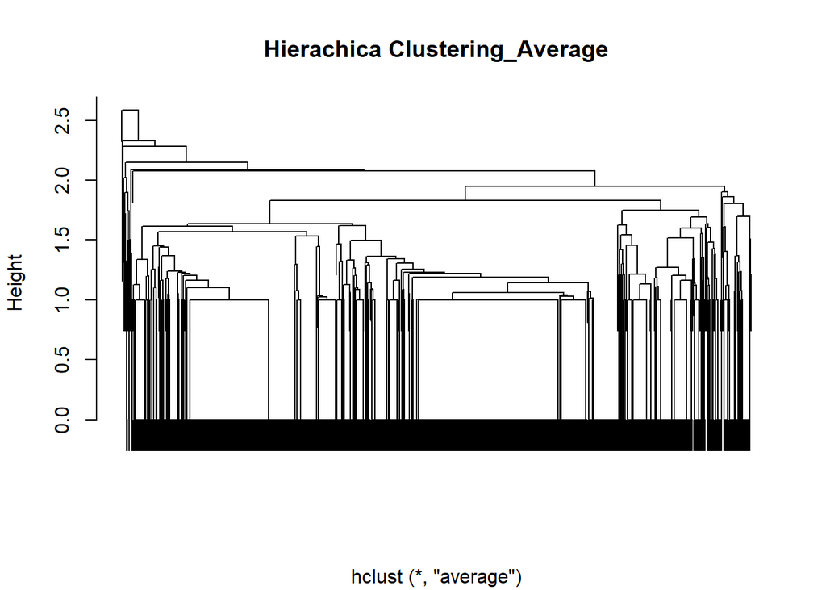

```r
# 제목을 제외한 영화 정보를 포함한 정보 추출
movie1 <- movie[,-1]

# average linkage
hc_avg <- hclust(dist(movie1), method = "average")
plot(hc_avg, cex = 0.3, xlab="", main="Hierachica Clustering_Average", label = FALSE)
```

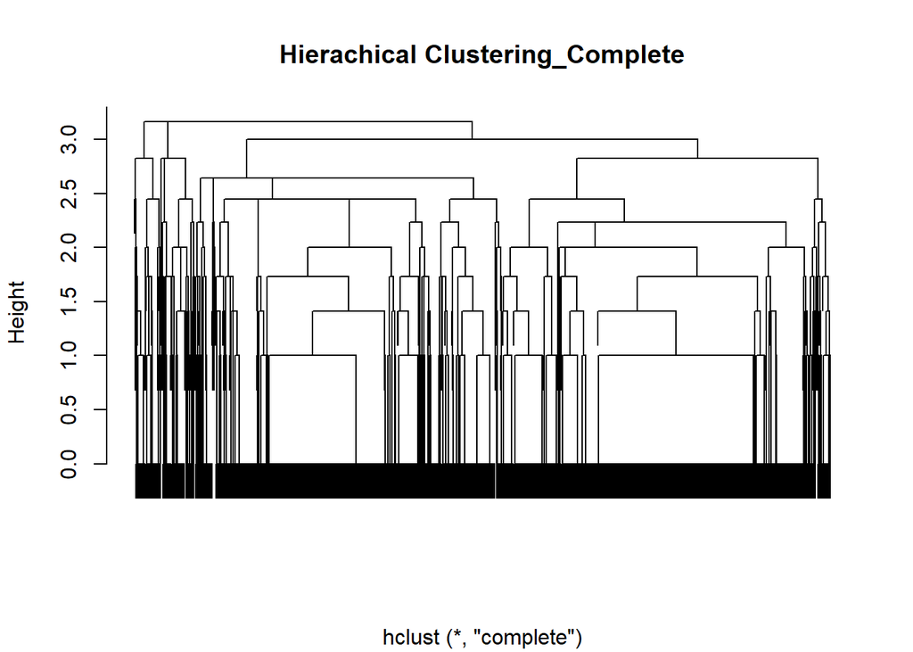

```r
# complete linkage
hc_com <- hclust(dist(movie1), method = "complete")
plot(hc_com, cex = 0.3, xlab="", main="Hierachical Clustering_Complete", label = FALSE)
```

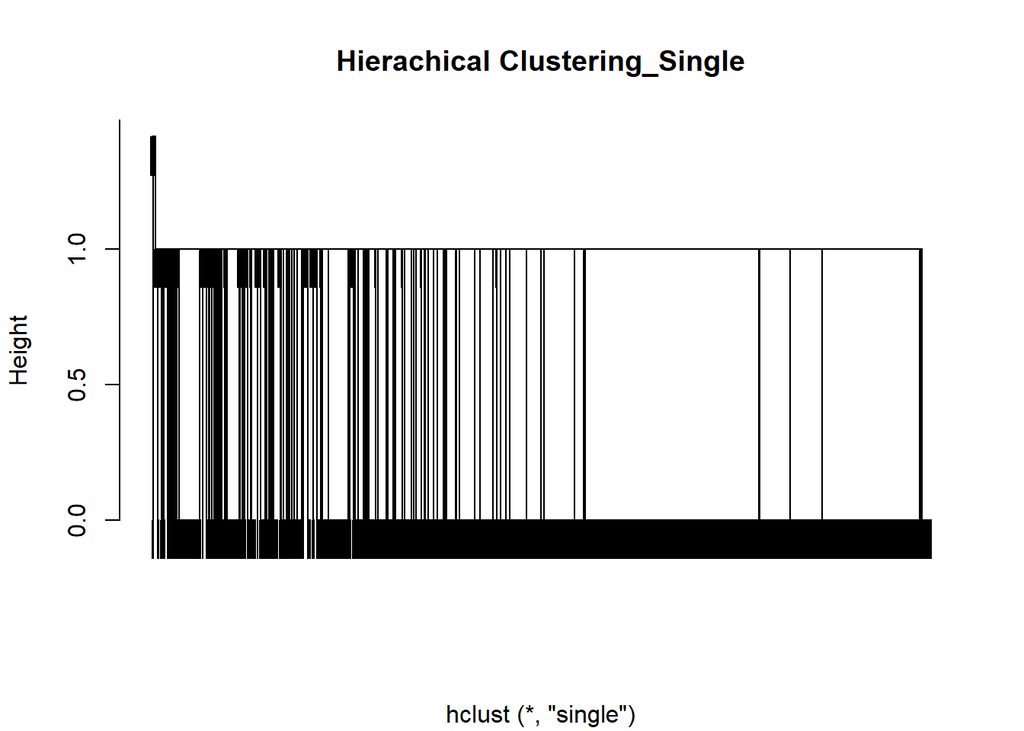

```r
# single linkage
hc_sin <- hclust(dist(movie1), method = "single")
plot(hc_sin, cex = 0.3, xlab="", main="Hierachical Clustering_Single", label = FALSE)
```

**B. 세 dendrogram의 형태를 비교해보자. 어떠한 특성을 가지는가?**

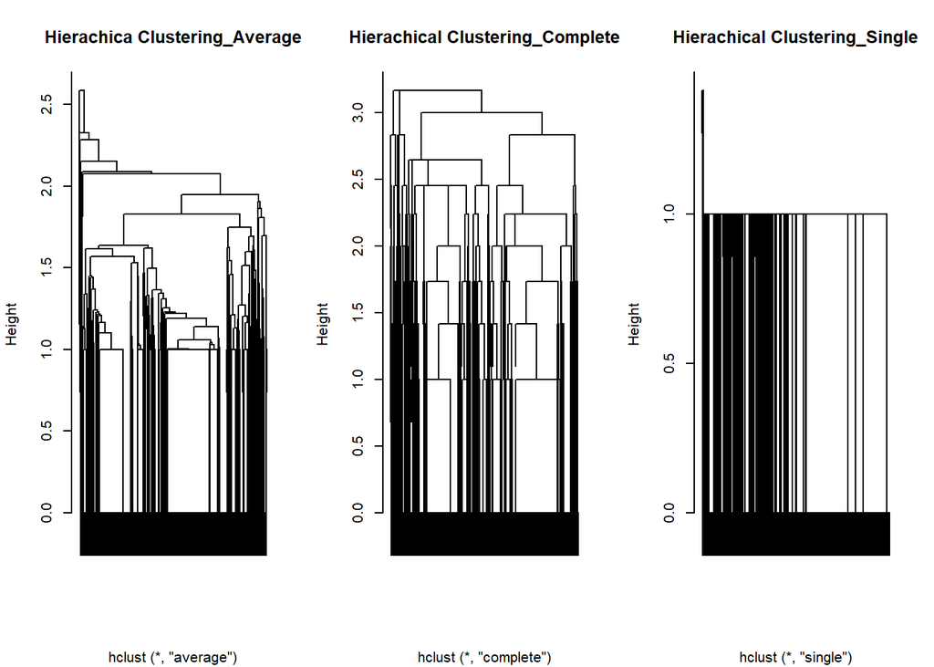

```r
par(mfrow = c(1,3))
plot(hc_avg, cex = 0.3, xlab="", main="Hierachica Clustering_Average", label = FALSE)
plot(hc_com, cex = 0.3, xlab="", main="Hierachical Clustering_Complete", label = FALSE)
plot(hc_sin, cex = 0.3, xlab="", main="Hierachical Clustering_Single", label = FALSE)
```

- Average/Compelte linkage clustering과는 다르게 Single linkage clustering은 한쪽으로 치우친 경향이 있다.
- Single linkage clustering이 한쪽으로 치우친 이유는 가장 가까운 dissimilarity를 가진 cluster끼리 하나씩 합쳐지는 경향이 있기 때문이다.
- 각 linkage Clustering마다 dissimilarity를 나타내는 height가 다르다.

**C. 세 dendrogram이 가지는 height 값의 범위는 어떻게 다른가? 이러한 차이가 발생하는 이유는 무엇인가?**

- height의 최대값은 Complete가 가장 크고, Average, Single이 그 다음이다.
- height는 dissimilarity를 나타낸다.
- 각 Clustering은 dissimilarity가 최대 거리, 평균 거리, 최소 거리로 구해지기 때문에 height의 범위가 다르다.

**D. 세 경우에 대해서, 각각 10개의 cluster를 생성해보자. 그리고 각 cluster에 속하는 영화의 수가 어떠한 분포를 가지는지 비교해보자.**

```r
# Single likage cluster 10개 생성
cluster_sin <- cutree(hc_sin, k=10)
a <- table(cluster_sin)

# Average likage cluster 10개 생성
cluster_avg <- cutree(hc_avg, k=10)
b <- table(cluster_avg)

# Complete likage cluster 10개 생성
cluster_com <- cutree(hc_com, k=10)
c <- table(cluster_com)

cluster_all <- bind_rows(a, b, c)
cluster_all <- cbind("종류"=c("Single", "Average", "Complete"),cluster_all)
cluster_all
```

```
##       종류    1   2 3  4  5  6  7  8  9 10
## 1   Single 1654   1 1  1  2  1  1  1  1  1
## 2  Average 1554   1 1 80 16  1  3  5  2  1
## 3 Complete  686 735 7 40 57 24 25 38 50  2
```

- single과 average는 cluster-1에 많은 영화가 속해있다.
- single은 cluster-1에 대부분의 영화가 속해 있는 반면, average는 비교적 다수의 영화들이 cluster-4,cluster-5에 속해 있다.
- complete는 cluster-1, cluster-2에 대부분의 영화가 속해 있다. 하지만 single/average 보다 비교적 다수의 영화가 cluster-4에서 cluster-7까지 분포되어 있다.